# Assignment: K Nearest Neighbor

### By Breton Shindel and Julie Kiani

# Problem 1 (30 points)

In this problem, you are required to implement a Nearest Neighbor Classifier and run it on a 2-dimensional toy dataset. (You’re not allowed to use built-in knn functions in R to do this problem). You have to experiment with different distance measures and observe their influence on the classification performance. The training data has two classes as shown in figure 1. The training set along with test points and their correct label are saved in knnData.csv available under Data folder on Canvas.

Apply 3-NN and report your accuracy rate on test points for the following distance measures:

- L2 Norm
- L1 Norm
- L-infinity Norm

## Importing Modules and Loading the Data

```python
import pandas as pd
import numpy as np
import matplotlib.pyplot as plt
import seaborn as sns
from sklearn.preprocessing import StandardScaler
from math import sqrt
from sklearn.metrics.pairwise import euclidean_distances
from math import *
import scipy as sci
import warnings
warnings.filterwarnings('ignore')
```

```python
%cd ~/PythonAnalytics/
```

```
[Errno 2] No such file or directory: '/Users/bretonshindel/PythonAnalytics/'
/Users/bretonshindel/Desktop/Analytics_Work/Python_Analytics
```

```python
#read in the data file, give shape and display top rows
Data = pd.read_csv('knnData.csv')
print('Rows:', Data.shape[0])
print('Features:', Data.shape[1])
Data.head(3)
```

```
Rows: 40
Features: 6
```

|  | trainPoints_x1 | trainPoints_x2 | trainLabel | testPoints_x1 | testPoints_x2 | testLabel |
| --- | --- | --- | --- | --- | --- | --- |
| 0 | 1.947005 | 4.256560 | -1 | -1.888977 | -4.622611 | 1 |
| 1 | 0.794931 | 3.556851 | -1 | 4.233796 | 3.851680 | 1 |
| 2 | -0.264977 | 2.128280 | -1 | -0.697926 | 4.132868 | -1 |

## Breaking into Training and Test Data Frames

```python
#the Training points and labels are avaialable in the first three columns
Train = Data.iloc[:, :3]
Train.head(3)
```

|  | trainPoints_x1 | trainPoints_x2 | trainLabel |
| --- | --- | --- | --- |
| 0 | 1.947005 | 4.256560 | -1 |
| 1 | 0.794931 | 3.556851 | -1 |
| 2 | -0.264977 | 2.128280 | -1 |

```python
#the Test points and labels are avaialable in the last three columns
Test = Data.iloc[:, 3:]
Test.head(3)
```

|  | testPoints_x1 | testPoints_x2 | testLabel |
| --- | --- | --- | --- |
| 0 | -1.888977 | -4.622611 | 1 |
| 1 | 4.233796 | 3.851680 | 1 |
| 2 | -0.697926 | 4.132868 | -1 |

```python
#separating out the Train and Test data points from the label columns
X_Train = Train.iloc[:, 0:2]
y_Train = Train.iloc[:, 2]
X_Test = Test.iloc[:, 0:2]
y_Test = Test.iloc[:, 2]
```

## Standardizing the Values

```python
sc = StandardScaler()
sc.fit(X_Train)
X_Train = sc.transform(X_Train)
sc.fit(X_Test)
X_Test = sc.transform(X_Test)

X_Train = pd.DataFrame(X_Train)
X_Test = pd.DataFrame(X_Test)
```

```python
#dispaly unique Train labels and post-standardized Train data points
print('Unique y values:', pd.unique(y_Train))
X_Train.head(3)
```

```
Unique y values: [-1  1]
```

|  | 0 | 1 |
| --- | --- | --- |
| 0 | 0.353972 | 1.679644 |
| 1 | -0.123401 | 1.414829 |
| 2 | -0.562583 | 0.874165 |

```python
#dispaly unique Test labels and post-standardized Test data points
print('Unique y values:', pd.unique(y_Test))
X_Test.head(3)
```

```
Unique y values: [ 1 -1]
```

|  | 0 | 1 |
| --- | --- | --- |
| 0 | -0.657660 | -1.700896 |
| 1 | 1.652897 | 1.193795 |
| 2 | -0.208192 | 1.289845 |

## Scatter Plot of the Data Points

```python
%matplotlib inline
sns.set_context('poster')
sns.mpl.rc("figure", figsize=(12,6))
```

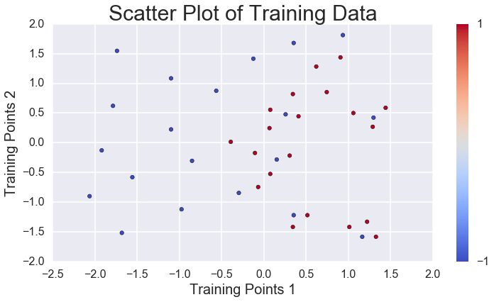

```python
plt.scatter(X_Train.iloc[:, 0], X_Train.iloc[:, 1], c=y_Train, cmap='coolwarm', s=30)

plt.xlabel('Training Points 1', size=20)
plt.ylabel('Training Points 2', size=20)
plt.title('Scatter Plot of Training Data', size=30)
cbar = plt.colorbar()
cbar.set_ticks([-1, 1])
plt.show();
```

# KNN with $L_{2}$ Norm - Euclidean

```python
#separating out the x1 and x2 columns for both the Train and Test data to
#better understand the matrices generated below
x11 = X_Train.iloc[:, 0].values
x21 = X_Train.iloc[:, 1].values
x12 = X_Test.iloc[:, 0].values
x22 = X_Test.iloc[:, 1].values
#x12 = pd.DataFrame(x12)
#x12
```

```python
#initial eculidean distance calcultion based on individual vectors defined above
L2_vals = np.sqrt(abs(x11-x12)**2 + abs(x21-x22)**2)
L2_vals
```

```
array([ 3.52866091,  1.78999674,  0.54624444,  0.66770188,  2.70592716,
        2.16266833,  0.75484811,  3.31137792,  3.64723268,  0.92483074,
        3.70104574,  1.20103657,  2.35470253,  2.67418772,  1.26068437,
        2.18044306,  2.50945808,  1.34031768,  1.53612063,  1.73716195,
        3.98007456,  1.569805  ,  1.30308127,  1.84124008,  1.50348844,
        0.7775101 ,  0.8098014 ,  1.35872132,  2.32003445,  1.21479357,
        1.82812288,  0.88232363,  2.62764657,  1.55957514,  1.94241038,
        0.70360171,  2.39750481,  0.59338415,  1.22699684,  1.57358994])
```

```python
#calculating specific distance between the 1st Train point and the 2nd Test point
#to determine direction the euclidean_distances matrix below is dispaying the
#results
x1a = 0.353972
x1b = 1.652897
x2a = 1.679644
x2b = 1.193795
Next = np.sqrt(abs(x1a-x1b)**2 + abs(x2a-x2b)**2)
Next
```

```
1.3868148421566593
```

We see in comparing the "L2_vals" array above and the "Xs" matrix below that the first values match. These values represent the distance between the 1st Train point and the 1st Test point. The "Next" calculation just above finds the distance between 1st Train point and the 2nd Test point, which we then see matches the matrix value [0:1]. So **Row 0** contains distances between the 1st Train point and each Test point, and **Column 0** contains distances between the 1st Test point and each Train point.

```python
#use euclidean_distances function to generate 40x40 distance matrix
Xs = euclidean_distances(X_Train, X_Test)
Xs= pd.DataFrame(Xs)
print('Rows:', Xs.shape[0])
print('Features:', Xs.shape[1])
Xs.head()
```

```
Rows: 40
Features: 40
```

|  | 0 | 1 | 2 | 3 | 4 | 5 | 6 | 7 | 8 | 9 | ... | 30 | 31 | 32 | 33 | 34 | 35 | 36 | 37 | 38 | 39 |
| --- | --- | --- | --- | --- | --- | --- | --- | --- | --- | --- | --- | --- | --- | --- | --- | --- | --- | --- | --- | --- | --- |
| 0 | 3.528661 | 1.386815 | 0.684084 | 1.684792 | 3.402056 | 3.020425 | 2.422492 | 2.128437 | 3.275407 | 1.227829 | ... | 3.227995 | 2.692651 | 0.528755 | 3.654974 | 1.867361 | 2.940718 | 0.412300 | 1.279051 | 1.969304 | 2.447661 |
| 1 | 3.161198 | 1.789997 | 0.151032 | 1.139027 | 3.371255 | 3.078841 | 2.099753 | 1.585210 | 2.873620 | 0.798451 | ... | 3.251675 | 2.450941 | 0.337032 | 3.255411 | 1.577140 | 2.748207 | 0.860237 | 0.838402 | 1.568439 | 2.599136 |
| 2 | 2.576816 | 2.238418 | 0.546244 | 0.571857 | 3.194617 | 3.028249 | 1.605795 | 0.931718 | 2.256919 | 0.363966 | ... | 3.149221 | 2.045002 | 0.769198 | 2.635808 | 1.180527 | 2.391167 | 1.442998 | 0.350112 | 1.001355 | 2.691952 |
| 3 | 1.973634 | 2.916399 | 1.388604 | 0.667702 | 3.182463 | 3.181279 | 1.293464 | 0.414226 | 1.604488 | 0.906325 | ... | 3.232567 | 1.813190 | 1.571415 | 1.959995 | 1.173595 | 2.194267 | 2.237725 | 0.848703 | 0.737070 | 3.026642 |
| 4 | 1.407495 | 2.917244 | 1.720133 | 1.229837 | 2.705927 | 2.786503 | 0.772237 | 0.977221 | 1.056930 | 1.094256 | ... | 2.799840 | 1.289754 | 1.797984 | 1.429530 | 0.875261 | 1.668935 | 2.410039 | 1.044095 | 0.444786 | 2.747035 |

5 rows × 40 columns

Below we find the matrix locations of the 3 shortest distances in each column. As noted above, each column represents the distances between a given Test point and each of the 40 Train points. So the 3 shortest distances are the 3 nearest neighbors.

```python
#find the matrix locations of the 3 shortest distances per column
XsMin3 = np.array([Xs[c].nsmallest(3).index.values for c in Xs])
XsMin3 = pd.DataFrame(XsMin3)
XsMin3.head()
```

|  | 0 | 1 | 2 |
| --- | --- | --- | --- |
| 0 | 13 | 5 | 17 |
| 1 | 30 | 20 | 18 |
| 2 | 1 | 2 | 0 |
| 3 | 9 | 2 | 3 |
| 4 | 34 | 35 | 7 |

Our Train "y" values are ordered so those on rows indexed 0 to 19 are labeled with a "-1" and the remaining with a "1". We use this grouping to replace the shortest distance matrix loactions identified for "XsMin3" in the step above with their corresponding labels.

With the nearest neighbor lables in place, we find the most common label for each group of three to determine the final label to assign.

```python
#replace matrix indicies with their -1 and 1 labels
XsMin3[XsMin3<20] = -1
XsMin3[XsMin3!=-1] = 1
XsMin3.head()
```

|  | 0 | 1 | 2 |
| --- | --- | --- | --- |
| 0 | -1 | -1 | -1 |
| 1 | 1 | 1 | -1 |
| 2 | -1 | -1 | -1 |
| 3 | -1 | -1 | -1 |
| 4 | 1 | 1 | -1 |

```python
#count instances of the label being a 1 for each group of 3 and assign
#"winning" majority label (a count of 1's <2 means the -1's are the majority
#and the winning label)
XsCount1s = XsMin3[XsMin3 == 1].count(axis=1)
XsCount1s[XsCount1s<2] = -1
XsCount1s[XsCount1s!=-1] = 1
#XsCount1s
```

Next we check the resulting label assignments against those provided in the given dataset as the Test "y" values. We do this by bringing the "XsCount1s" and the "y_Test" vectors together and calculate the match frequency.

```python
#bring the "XsCount1s" and the "y_Test" vectors together
CkResults = pd.concat([XsCount1s, y_Test], axis=1, join_axes=[XsCount1s.index])
CkResults.columns = ['generatedLabel','testLabel']
CkResults.head()
```

|  | generatedLabel | testLabel |
| --- | --- | --- |
| 0 | -1 | 1 |
| 1 | 1 | 1 |
| 2 | -1 | -1 |
| 3 | -1 | -1 |
| 4 | 1 | 1 |

```python
#calc the match frequency by multiplying the generated label and the
#given y label together.  Those that match will return a positive 1 and those
#that don't will return a negative 1.
CkAccuracy = CkResults.generatedLabel * CkResults.testLabel

#then sum the matches and divide by 40
CkAccuracy = ((CkAccuracy==1).sum())/40
print(round(CkAccuracy,3))
```

```
0.675
```

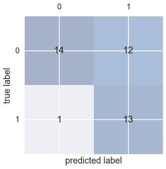

```python
from sklearn.metrics import confusion_matrix
confmatl2 = confusion_matrix(y_true=CkResults.testLabel, y_pred=CkResults.generatedLabel)

fig, ax = plt.subplots(figsize=(5, 5))
ax.matshow(confmatl2, cmap=plt.cm.Blues, alpha=0.3)
for i in range(confmatl2.shape[0]):
    for j in range(confmatl2.shape[1]):
        ax.text(x=j, y=i, s=confmatl2[i, j], va='center', ha='center')
plt.xlabel('predicted label')
plt.ylabel('true label')
plt.show();
```

# KNN with $L_{1}$ Norm - Manhattan

```python
abs(x11-x12)**2 + abs(x21-x22)**2
```

```
array([ 12.45144779,   3.20408834,   0.29838299,   0.4458258 ,
         7.32204178,   4.67713429,   0.56979566,  10.96522374,
        13.30230623,   0.85531189,  13.6977396 ,   1.44248884,
         5.54462399,   7.15127997,   1.58932509,   4.75433192,
         6.29737986,   1.79645147,   2.35966659,   3.01773163,
        15.8409935 ,   2.46428775,   1.6980208 ,   3.39016503,
         2.26047749,   0.60452196,   0.65577831,   1.84612363,
         5.38255987,   1.47572343,   3.34203326,   0.77849499,
         6.90452649,   2.43227461,   3.7729581 ,   0.49505536,
         5.74802929,   0.35210475,   1.50552124,   2.47618531])
```

```python
#equation per lecture notes
abs(x11-x12) + abs(x21-x22)
```

```
array([ 4.39217118,  1.99733142,  0.77007129,  0.70366204,  3.61824668,
        2.24903213,  1.0674823 ,  4.65629192,  4.96958678,  1.25797288,
        5.16257545,  1.60941889,  2.99010854,  3.77967444,  1.38906906,
        3.0836121 ,  3.46518574,  1.88279062,  1.66538831,  2.21215891,
        5.57906087,  2.03301947,  1.790016  ,  2.22464209,  2.07904771,
        1.08975562,  0.87209361,  1.73580235,  2.88017896,  1.51941291,
        2.15261813,  1.19159264,  2.82876186,  1.98355065,  2.74455355,
        0.77587162,  3.05835318,  0.64275422,  1.72875998,  2.22400609])
```

```python
#calculating specific distance between the 1st Train point and the 2nd Test point
#to determine direction the L1 matrix below is dispaying the results
Nextm = abs(x1a-x1b) + abs(x2a-x2b)
Nextm
#locating result on the Xm matrix below indicates Xm needs to be transposed for
#subsequent steps to work
```

```
1.784774
```

```python
Vec1 = []
for i in x12:
    for j in x11:
        Output = (abs(i - j))
        Vec1.append(Output)
#Vec1
```

```python
Vec2 = []
for i in x22:
    for j in x21:
        Output = (abs(i - j))
        Vec2.append(Output)
```

```python
Vec1 = np.asarray(Vec1)
Vec2 = np.asarray(Vec2)
```

```python
#Seperate the 40 arrays into a dataframe
Vec = Vec1 + Vec2
Vectors = np.split(Vec, 40)
Xm = pd.DataFrame(Vectors)
Xm.head()
```

|  | 0 | 1 | 2 | 3 | 4 | 5 | 6 | 7 | 8 | 9 | ... | 30 | 31 | 32 | 33 | 34 | 35 | 36 | 37 | 38 | 39 |
| --- | --- | --- | --- | --- | --- | --- | --- | --- | --- | --- | --- | --- | --- | --- | --- | --- | --- | --- | --- | --- | --- |
| 0 | 4.392171 | 3.649984 | 2.670137 | 2.363639 | 1.585775 | 1.216169 | 1.490241 | 1.937653 | 5.106973 | 3.224287 | ... | 4.388219 | 1.950404 | 1.282082 | 1.652547 | 2.099960 | 2.248719 | 1.544613 | 1.981343 | 3.521975 | 3.956070 |
| 1 | 1.784774 | 1.997331 | 2.535110 | 3.720770 | 4.002167 | 3.989078 | 3.715006 | 3.267594 | 1.334787 | 2.860122 | ... | 0.817028 | 3.254843 | 3.923165 | 3.552700 | 3.105287 | 2.956528 | 3.660634 | 3.223904 | 1.683272 | 1.249177 |
| 2 | 0.951963 | 0.209775 | 0.770071 | 1.955732 | 2.237128 | 2.224040 | 3.074295 | 4.249948 | 1.666765 | 1.095083 | ... | 2.353135 | 3.931680 | 3.263358 | 3.236601 | 4.412255 | 4.053452 | 2.179747 | 1.458866 | 1.023465 | 1.391356 |
| 3 | 2.278003 | 1.535816 | 0.587316 | 0.703662 | 1.481526 | 2.575942 | 3.600323 | 4.775977 | 2.992805 | 0.230957 | ... | 2.879163 | 4.457708 | 3.789386 | 3.762629 | 4.938283 | 4.579480 | 2.705775 | 1.619819 | 1.549493 | 1.917384 |
| 4 | 4.401380 | 4.613938 | 4.512456 | 4.396110 | 3.618247 | 2.523831 | 1.499450 | 0.511370 | 3.951393 | 5.256759 | ... | 2.220609 | 0.642064 | 1.310386 | 1.337143 | 0.349064 | 0.520292 | 2.393998 | 3.479954 | 3.550279 | 3.182388 |

5 rows × 40 columns

```python
Xm = Xm.transpose()
Xm.head()
```

|  | 0 | 1 | 2 | 3 | 4 | 5 | 6 | 7 | 8 | 9 | ... | 30 | 31 | 32 | 33 | 34 | 35 | 36 | 37 | 38 | 39 |
| --- | --- | --- | --- | --- | --- | --- | --- | --- | --- | --- | --- | --- | --- | --- | --- | --- | --- | --- | --- | --- | --- |
| 0 | 4.392171 | 1.784774 | 0.951963 | 2.278003 | 4.401380 | 4.126582 | 2.893395 | 2.953910 | 4.254785 | 1.689096 | ... | 4.333389 | 2.812034 | 0.700284 | 4.723175 | 2.176704 | 3.105216 | 0.543643 | 1.768074 | 2.598956 | 3.442998 |
| 1 | 3.649984 | 1.997331 | 0.209775 | 1.535816 | 4.613938 | 4.339139 | 2.151207 | 2.211723 | 3.512597 | 0.946909 | ... | 4.545947 | 2.780281 | 0.474790 | 3.980987 | 1.707895 | 3.317774 | 0.952982 | 1.025887 | 1.856769 | 3.655556 |
| 2 | 2.670137 | 2.535110 | 0.770071 | 0.587316 | 4.512456 | 4.237658 | 1.945525 | 1.231876 | 2.532751 | 0.513671 | ... | 4.444466 | 2.678800 | 1.021750 | 3.001140 | 1.606414 | 3.216293 | 1.932829 | 0.492988 | 1.111949 | 3.554075 |
| 3 | 2.363639 | 3.720770 | 1.955732 | 0.703662 | 4.396110 | 4.121312 | 1.829178 | 0.583977 | 1.825956 | 1.218598 | ... | 4.328119 | 2.562453 | 2.207410 | 2.094563 | 1.490068 | 3.099947 | 3.118490 | 1.139620 | 0.995603 | 3.437728 |
| 4 | 1.585775 | 4.002167 | 2.237128 | 1.481526 | 3.618247 | 3.343448 | 1.051315 | 1.361841 | 1.065694 | 1.499995 | ... | 3.550256 | 1.784590 | 2.488807 | 1.534084 | 1.012387 | 2.322083 | 3.399886 | 1.421017 | 0.590135 | 2.831523 |

5 rows × 40 columns

```python
#repeat steps above to find the matrix locations of the 3 shortest distances
#per column
XmMin3 = np.array([Xm[c].nsmallest(3).index.values for c in Xm])
XmMin3 = pd.DataFrame(XmMin3)
XmMin3.head()
```

|  | 0 | 1 | 2 |
| --- | --- | --- | --- |
| 0 | 13 | 17 | 5 |
| 1 | 30 | 20 | 21 |
| 2 | 1 | 2 | 21 |
| 3 | 9 | 2 | 3 |
| 4 | 34 | 7 | 35 |

```python
#replace matrix indicies with their -1 and 1 labels
XmMin3[XmMin3<20] = -1
XmMin3[XmMin3!=-1] = 1
#XmMin3
```

```python
#count instances of the label being a 1 for each group of 3 and assign
#"winning" majority label (a count of 1's <2 means the -1's are the majority
#and the winning label)
XmCount1s = XmMin3[XmMin3 == 1].count(axis=1)
XmCount1s[XmCount1s<2] = -1
XmCount1s[XmCount1s!=-1] = 1
#XmCount1s
```

```python
#y_Test
```

```python
#bring the "XmCount1s" and the "y_Test" vectors together
CkResultm = pd.concat([XmCount1s, y_Test], axis=1, join_axes=[XmCount1s.index])
CkResultm.columns = ['generatedLabel','testLabel']
CkResultm.head()
```

|  | generatedLabel | testLabel |
| --- | --- | --- |
| 0 | -1 | 1 |
| 1 | 1 | 1 |
| 2 | -1 | -1 |
| 3 | -1 | -1 |
| 4 | 1 | 1 |

```python
#calc the match frequency by multiplying the generated label and the
#given y label together.  Those that match will return a positive 1 and those
#that don't will return a negative 1.
CkAccm = CkResultm.generatedLabel * CkResultm.testLabel

#then sum the matches and divide by 40
CkAccm = ((CkAccm==1).sum())/40
print(round(CkAccm,3))
```

```
0.7
```

```python
confmatl1 = confusion_matrix(y_true=CkResultm.testLabel, y_pred=CkResultm.generatedLabel)
print(confmatl1)
```

```
[[15 11]
 [ 1 13]]
```

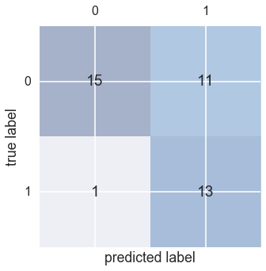

```python
fig, ax = plt.subplots(figsize=(5, 5))
ax.matshow(confmatl1, cmap=plt.cm.Blues, alpha=0.3)
for i in range(confmatl1.shape[0]):
    for j in range(confmatl1.shape[1]):
        ax.text(x=j, y=i, s=confmatl1[i, j], va='center', ha='center')
plt.xlabel('predicted label')
plt.ylabel('true label')
plt.show();
```

# KNN with $L_{\infty}$ Norm - Infinity

```python
Linf1 = abs(x11-x12)
Linf2 = abs(x21-x22)
Linf1 = pd.Series(Linf1)
Linf2 = pd.Series(Linf2)
```

```python
#apply first part of chebyshev distance calculation
Linf_Vecs = abs(X_Train-X_Test)
Linf_Vecs.head()
```

|  | 0 | 1 |
| --- | --- | --- |
| 0 | 1.011631 | 3.380540 |
| 1 | 1.776297 | 0.221034 |
| 2 | 0.354392 | 0.415679 |
| 3 | 0.036985 | 0.666677 |
| 4 | 2.432095 | 1.186152 |

```python
Linf_Vecs['Max'] = Linf_Vecs[[0,1]].max(axis=1)
Linf_Vecs = Linf_Vecs.sort(['Max'], ascending=[False])
Linf_Vecs.head(7)
```

|  | 0 | 1 | Max |
| --- | --- | --- | --- |
| 0 | 1.011631 | 3.380540 | 3.380540 |
| 8 | 1.794174 | 3.175413 | 3.175413 |
| 20 | 2.416681 | 3.162380 | 3.162380 |
| 10 | 2.150215 | 3.012360 | 3.012360 |
| 32 | 0.209479 | 2.619283 | 2.619283 |
| 7 | 2.577842 | 2.078450 | 2.577842 |
| 4 | 2.432095 | 1.186152 | 2.432095 |

```python
import scipy as sci

#Testing the first values to see if it corresponds to our distances
#sci.spatial.distance.chebyshev(x11[0], x12[0])
sci.spatial.distance.chebyshev(X_Train.iloc[0, 0:2], X_Test.iloc[0, 0:2])
```

```
3.3805398845975296
```

```python
from operator import itemgetter
import collections as col

#K=3
match=0
InfDist = []
for c in range(len(X_Train)):
    for d in (range(len(X_Train))):
        InfDist.append((X_Train.iloc[d],
                        sci.spatial.distance.chebyshev(X_Train.iloc[d, 0:2], X_Test.iloc[c, 0:2])))
```

```python
Vec3 = []
for i in x22:
    for j in x21:
        Output = sci.spatial.distance.chebyshev(i, j)
        Vec3.append(Output)
```

```python
Vec3 = np.array(Vec3)
```

```python
len(Vec3)
```

```
1600
```

```python
#InfDist = pd.DataFrame(InfDist)
#InfDist = InfDist[[1]]
#InfDist = InfDist.as_matrix()
#InfDist = np.array(InfDist)
```

```python
#bring the arrays into a dataframe
z = np.split(Vec3, 40)
Xc = pd.DataFrame(z)
Xc.head()
```

|  | 0 | 1 | 2 | 3 | 4 | 5 | 6 | 7 | 8 | 9 | 10 | 11 | 12 | 13 | 14 | 15 | 16 | 17 | 18 | 19 | 20 | 21 | 22 | 23 | 24 | 25 | 26 | 27 | 28 | … |
| --- | --- | --- | --- | --- | --- | --- | --- | --- | --- | --- | --- | --- | --- | --- | --- | --- | --- | --- | --- | --- | --- | --- | --- | --- | --- | --- | --- | --- | --- | --- |
| 0 | 3.380540 | 3.115725 | 2.575061 | 1.924058 | 1.394428 | 0.853764 | 0.478609 | 0.114489 | 3.512947 | 2.784706 | 3.248132 | 1.570971 | 2.321280 | 0.577915 | 2.177839 | 1.416496 | 0.798594 | 0.180693 | 2.122669 | 1.118579 | 3.137793 | 2.983317 | 2.255076 | 1.946126 | 2.144737 | 1.482699 | 1.173749 | 1.526835 | 1.968193 | … |
| 1 | 0.485849 | 0.221034 | 0.319630 | 0.970633 | 1.500263 | 2.040927 | 2.416081 | 2.780202 | 0.618256 | 0.109985 | 0.353442 | 1.323720 | 0.573411 | 2.316776 | 0.716852 | 1.478195 | 2.096097 | 2.713998 | 0.772022 | 1.776112 | 0.243102 | 0.088627 | 0.639615 | 0.948565 | 0.749954 | 1.411991 | 1.720942 | 1.367856 | 0.926497 | … |
| 2 | 0.389799 | 0.124984 | 0.415679 | 1.066683 | 1.596313 | 2.136977 | 2.512131 | 2.876252 | 0.522207 | 0.206034 | 0.257392 | 1.419769 | 0.669460 | 2.412826 | 0.812902 | 1.574245 | 2.192146 | 2.810048 | 0.868072 | 1.872162 | 0.147052 | 0.007423 | 0.735664 | 1.044615 | 0.846004 | 1.508041 | 1.816992 | 1.463905 | 1.022547 | … |
| 3 | 0.789805 | 0.524991 | 0.015673 | 0.666677 | 1.196307 | 1.736971 | 2.112125 | 2.476246 | 0.922213 | 0.193972 | 0.657398 | 1.019763 | 0.269454 | 2.012819 | 0.412896 | 1.174239 | 1.792140 | 2.410042 | 0.468066 | 1.472156 | 0.547058 | 0.392583 | 0.335658 | 0.644609 | 0.445998 | 1.108035 | 1.416986 | 1.063899 | 0.622541 | … |
| 4 | 3.172264 | 2.907449 | 2.366785 | 1.715782 | 1.186152 | 0.645488 | 0.270333 | 0.093787 | 3.304671 | 2.576430 | 3.039856 | 1.362695 | 2.113004 | 0.369639 | 1.969563 | 1.208220 | 0.590318 | 0.027583 | 1.914393 | 0.910303 | 2.929517 | 2.775041 | 2.046800 | 1.737850 | 1.936461 | 1.274423 | 0.965473 | 1.318559 | 1.759917 | … |

```python
print(Xc.shape[0])
print(Xc.shape[1])
```

```
40
40
```

```python
Xc = Xc.transpose()
Xc.head()
```

|  | 0 | 1 | 2 | 3 | 4 | 5 | 6 | 7 | 8 | 9 | 10 | 11 | 12 | 13 | 14 | 15 | 16 | 17 | 18 | 19 | 20 | 21 | 22 | 23 | 24 | 25 | 26 | 27 | 28 | … |
| --- | --- | --- | --- | --- | --- | --- | --- | --- | --- | --- | --- | --- | --- | --- | --- | --- | --- | --- | --- | --- | --- | --- | --- | --- | --- | --- | --- | --- | --- | --- |
| 0 | 3.380540 | 0.485849 | 0.389799 | 0.789805 | 3.172264 | 2.614937 | 2.363922 | 1.187601 | 3.043005 | 1.045845 | 3.144768 | 1.276313 | 1.821426 | 0.848326 | 1.066991 | 0.422476 | 0.466193 | 2.367999 | 1.122639 | 2.833761 | 3.405127 | 0.967804 | 1.801449 | 1.870108 | 0.419055 | 1.426237 | 1.399594 | 0.573724 | 0.758019 | … |
| 1 | 3.115725 | 0.221034 | 0.124984 | 0.524991 | 2.907449 | 2.350123 | 2.099107 | 0.922786 | 2.778190 | 0.781030 | 2.879953 | 1.011498 | 1.556611 | 0.583511 | 0.802176 | 0.157661 | 0.201378 | 2.103184 | 0.857824 | 2.568947 | 3.140312 | 0.702989 | 1.536634 | 1.605293 | 0.154240 | 1.161422 | 1.134779 | 0.308909 | 0.493204 | … |
| 2 | 2.575061 | 0.319630 | 0.415679 | 0.015673 | 2.366785 | 1.809459 | 1.558443 | 0.382123 | 2.237526 | 0.240366 | 2.339289 | 0.470834 | 1.015947 | 0.042848 | 0.261512 | 0.383003 | 0.339286 | 1.562521 | 0.317160 | 2.028283 | 2.599648 | 0.162325 | 0.995970 | 1.064629 | 0.386424 | 0.620758 | 0.594116 | 0.231755 | 0.047460 | … |
| 3 | 1.924058 | 0.970633 | 1.066683 | 0.666677 | 1.715782 | 1.158455 | 0.907439 | 0.268881 | 1.586523 | 0.410637 | 1.688285 | 0.180169 | 0.364944 | 0.608156 | 0.389491 | 1.034006 | 0.990290 | 0.911517 | 0.333843 | 1.377279 | 1.948645 | 0.488678 | 0.344966 | 0.413626 | 1.037428 | 0.030245 | 0.056888 | 0.882758 | 0.698463 | … |
| 4 | 1.394428 | 1.500263 | 1.596313 | 1.196307 | 1.186152 | 0.628825 | 0.377809 | 0.798511 | 1.056893 | 0.940267 | 1.158656 | 0.709799 | 0.164686 | 1.137786 | 0.919121 | 1.563636 | 1.519920 | 0.381887 | 0.863473 | 0.847649 | 1.419015 | 1.018308 | 0.184664 | 0.116004 | 1.567057 | 0.559875 | 0.586518 | 1.412388 | 1.228093 | … |

```python
#repeat steps above to find the matrix locations of the 3 shortest distances
#per column
XcMin3 = np.array([Xc[c].nsmallest(3).index.values for c in Xc])
XcMin3 = pd.DataFrame(XcMin3)
XcMin3.head()
```

|  | 0 | 1 | 2 |
| --- | --- | --- | --- |
| 0 | 7 | 34 | 17 |
| 1 | 21 | 9 | 1 |
| 2 | 21 | 1 | 20 |
| 3 | 2 | 39 | 38 |
| 4 | 17 | 31 | 32 |

```python
#replace matrix indicies with their -1 and 1 labels
XcMin3[XcMin3<20] = -1
XcMin3[XcMin3!=-1] = 1
#XcMin3
```

```python
#count instances of the label being a 1 for each group of 3 and assign
#"winning" majority label (a count of 1's <2 means the -1's are the majority
#and the winning label)
XcCount1s = XcMin3[XcMin3 == 1].count(axis=1)
XcCount1s[XcCount1s<2] = -1
XcCount1s[XcCount1s!=-1] = 1
#XcCount1s
```

```python
#bring the "XmCount1s" and the "y_Test" vectors together
CkResultc = pd.concat([XcCount1s, y_Test], axis=1, join_axes=[XcCount1s.index])
CkResultc.columns = ['generatedLabel','testLabel']
CkResultc.head()
```

|  | generatedLabel | testLabel |
| --- | --- | --- |
| 0 | -1 | 1 |
| 1 | -1 | 1 |
| 2 | 1 | -1 |
| 3 | 1 | -1 |
| 4 | 1 | 1 |

```python
#calc the match frequency by multiplying the generated label and the
#given y label together.  Those that match will return a positive 1 and those
#that don't will return a negative 1.
CkAccc = CkResultc.generatedLabel * CkResultc.testLabel

#then sum the matches and divide by 40
CkAccc = ((CkAccc==1).sum())/40
print(round(CkAccc,3))
```

```
0.475
```

```python
ClassificationInf = pd.Series(CkResultc.generatedLabel == CkResultc.testLabel)
ClassificationInf = ClassificationInf.astype(int)
ClassificationInf.head()
```

```
0    0
1    0
2    0
3    0
4    1
dtype: int64
```

```python
sum(ClassificationInf)
```

```
19
```

```python
ClInfAccuracy = ((ClassificationInf==1).sum())/40
print(round(ClInfAccuracy, 3))
```

```
0.475
```

## Implementing KNN Via Scikit-Learn

To assess how valid our accuracy scores are, let's compare it with Python's built-in KNN function

```python
from sklearn.neighbors import KNeighborsClassifier

knn = KNeighborsClassifier(n_neighbors=3, p=2, metric='minkowski')
knn.fit(X_Train, y_Train)
```

```
KNeighborsClassifier(algorithm='auto', leaf_size=30, metric='minkowski',
           metric_params=None, n_jobs=1, n_neighbors=3, p=2,
           weights='uniform')
```

```python
print("Accuracy: %.03f" % knn.score(X_Test, y_Test))
```

```
Accuracy: 0.675
```

```python
X_Test_Reg = Test.iloc[:, 0:1]
y_Test_Reg = Test.iloc[:, 2]
X_Train_Reg = Train.iloc[:, 0:1]
y_Train_Reg = Train.iloc[:, 2]
```

```python
knn2 = KNeighborsClassifier(n_neighbors=3, p=2, metric='euclidean')
knn2.fit(X_Train_Reg, y_Train_Reg)
```

```
KNeighborsClassifier(algorithm='auto', leaf_size=30, metric='euclidean',
           metric_params=None, n_jobs=1, n_neighbors=3, p=2,
           weights='uniform')
```

```python
print("Accuracy: %.03f" % knn2.score(X_Test_Reg, y_Test_Reg))
```

```
Accuracy: 0.775
```

## Plotting the Decision Boundaries

In the following steps, we will plot the decision boundaries of Python's KNN classifier by defining a function to generate a color map of the boundary, and circle the plotted test points

```python
X_Train_New = X_Train.rename(columns={'trainPoints_x1':'Points_x1', 'trainPoints_x2':'Points_x2'})
X_Test_New = X_Test.rename(columns={'testPoints_x1':'Points_x1', 'testPoints_x2':'Points_x2'})

Xframes = [X_Train_New, X_Test_New]
yframes = [y_Train, y_Test]

X = pd.concat(Xframes)
y = pd.concat(yframes)
X = X.set_index(np.arange(80))
X = X.values
```

```python
from matplotlib.colors import ListedColormap
from sklearn import neighbors

def plot_decision_regions(X, y, classifier, test_idx = None, resolution = 0.02):
    #setup marker generator and color map
    markers = ('s', 'x', 'o', '^', 'v')
    colors = ('red', 'blue', 'lightgreen', 'pink', 'cyan')
    cmap = ListedColormap(colors[:len(np.unique(y))])

    #plot the decision surface
    x1_min, x1_max = X[:, 0].min() - 1, X[:, 0].max() + 1
    x2_min, x2_max = X[:, 1].min() - 1, X[:, 1].max() + 1
    xx1, xx2 = np.meshgrid(np.arange(x1_min, x1_max, resolution),
                          np.arange(x2_min, x2_max, resolution))
    Z = classifier.predict(np.array([xx1.ravel(), xx2.ravel()]).T)
    Z = Z.reshape(xx1.shape)
    plt.contourf(xx1, xx2, Z, alpha=0.4, cmap=cmap)
    plt.xlim(xx1.min(), xx1.max())
    plt.ylim(xx2.min(), xx2.max())

    #plot all the samples
    X_Test, y_Test = X[test_idx, :], y[test_idx]
    for idx, cl in enumerate(np.unique(y)):
        plt.scatter(x=X[y == cl, 0], y=X[y == cl, 1],
                   alpha = 0.8, c = cmap(idx),
                   marker=markers[idx], label = cl)

    #highlight test samples
    if test_idx:
        X_Test, y_Test = X[test_idx, :], y[test_idx]
        plt.scatter(X_Test[:, 0], X_Test[:, 1], c='',
                   alpha=1, linewidth=1, marker='o',
                   s=55, label='Test Point')
```

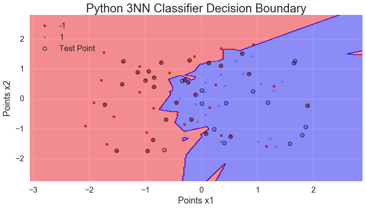

```python
X_combined = np.vstack((X_Train, X_Test))
y_combined = np.hstack((y_Train, y_Test))

plot_decision_regions(X_combined, y_combined, classifier = knn, test_idx = range(40, 80))
plt.xlabel('Points x1')
plt.ylabel('Points x2')
plt.title('Python 3NN Classifier Decision Boundary', size=24)
plt.legend(loc='upper left')
plt.show();
```

## Trying a Different ML Model

Looking at the scatter plot of the data, a good modeling choice could be a kernelized Support Vector Machine (SVM) because the points are not linearly seperable. The kernelized SVM is effective at precisely grouping clusters of data into classifications by changing the 'gamma' level.

To solve a nonlinear problem via SVM, we transform the training data into a higher dimensional feature space via mapping function phi(dot) and train a linear SVM model to classify the data in this new feature space. We can apply the same mapping function to transform new, unseen data to classify it using the linear SVM model.

```python
from sklearn.svm import SVC

svm = SVC(kernel = 'rbf', random_state=0, gamma=0.3, C=10)
svm.fit(X_Train, y_Train)

print("Accuracy: %.03f" % svm.score(X_Test, y_Test))
```

```
Accuracy: 0.725
```

Kernelized SVM is more effective for the job than our KNN classifier because we can set a tighter precision. With KNN=3 the model is underfitting (despite K being fairly low), but lowering K to 1 could result in strong overfitting in most scenarios. The precision from the kernelized SVM allows us to simply expand or contract the decision boundary while keeping a smooth shape, without reaching for outliers. This makes it easier (in this instance) to control the bias-variance tradeoff than KNN does.

Next we can show our classifier's decision boundary to see how the kernelized SVM compares.

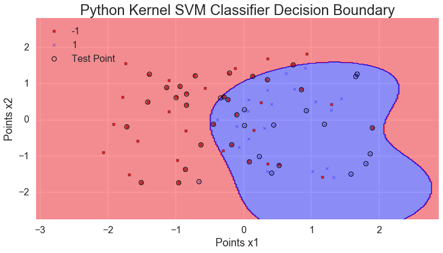

```python
plot_decision_regions(X_combined, y_combined, classifier = svm, test_idx = range(40, 80))
plt.legend(loc='upper left')
plt.xlabel('Points x1')
plt.ylabel('Points x2')
plt.title('Python Kernel SVM Classifier Decision Boundary', size=24)
plt.show();
```

### Extra credit points please! :)

# Problem 2 (30 points)

In this problem you apply KNN to the healthcare data to predict adherent class (pdc-80-flag). The data files for training and test are named healthcareTrain.csv and healthcareTest.csv, respectively.

1. Predict the pdc-80-flag using the following continuous features ”totallos”,”num-op”,”num-er”,”num-ndc”,”pre-total-cost”, and ”pre-CCI”. Determine the accuracy rate for test set for k = 31 to 101 with a step size of 2 and report it in a table. Use linear normalization method to normalize the input features and Euclidean distance for distance measure. Note that you must use the training parameters for normalization of test points. You can use built-in knn function in R for this problem.
2. Plot the accuracy rate vs. K. Which value of K gives you the best accuracy rate?
3. Create 3 more models with the same output and different combination of continuous input features. Justify your choice for those variable selections. Does any of your models outperform the base model in part 1?

```python
#import healthcare train and test data
HealthTrain = pd.read_csv('healthcareTrain.csv')
HealthTest = pd.read_csv('healthcareTest.csv')
```

```python
#size and view TRAIN data
print('Observations:', HealthTrain.shape[0])
print('Features:', HealthTrain.shape[1])

pd.set_option('display.max_columns', 100)
pd.set_option('display.max_rows', 20)
HealthTrain.head(3)
```

```
Observations: 1378
Features: 96
```

|  | patIndex | pdc | num_ip_post | total_los_post | num_op_post | num_er_post | num_ndc_post | num_gpi6_post | adjust_total_30d_post | generic_rate_post | post_ip_flag | post_er_flag | pdc_cat | post_ip_cost | post_er_cost | post_rx_cost | post_op_cost | post_total_cost | post_medical_cost | idx_copay | age_grpN | sexN | regionN | idx_prodtypeN | idx_paytypN | age_cat | log_idx_copay | ALCOHOL_DRUG | ASTHMA | … |
| --- | --- | --- | --- | --- | --- | --- | --- | --- | --- | --- | --- | --- | --- | --- | --- | --- | --- | --- | --- | --- | --- | --- | --- | --- | --- | --- | --- | --- | --- | --- |
| 0 | 2393 | 0.500000 | 0 | 0 | 2 | 0 | 3 | 2 | 2.333333 | 1.0 | 0 | 0 | 2 | 0.0 | 0.0 | 39.557654 | 250.832429 | 290.390082 | 250.832429 | 7.400208 | 3 | 1 | 2 | 2 | 4 | 3 | 2.001508 | 0 | 0 | … |
| 1 | 2148 | 0.994444 | 0 | 0 | 3 | 0 | 17 | 5 | 26.500000 | 1.0 | 0 | 0 | 1 | 0.0 | 0.0 | 547.646290 | 119.959732 | 667.606022 | 119.959732 | 13.998473 | 3 | 2 | 2 | 2 | 1 | 4 | 2.638948 | 0 | 0 | … |
| 2 | 1799 | 0.472222 | 0 | 0 | 3 | 0 | 3 | 1 | 3.000000 | 1.0 | 0 | 0 | 3 | 0.0 | 0.0 | 8.834483 | 1172.481506 | 1181.315989 | 1172.481506 | 2.946727 | 3 | 2 | 2 | 2 | 4 | 3 | 1.080695 | 0 | 0 | … |

```python
#size and view TEST data
print('Observations:', HealthTest.shape[0])
print('Features:', HealthTest.shape[1])

pd.set_option('display.max_columns', 100)
pd.set_option('display.max_rows', 20)
HealthTest.head(3)
```

```
Observations: 344
Features: 96
```

|  | patIndex | pdc | num_ip_post | total_los_post | num_op_post | num_er_post | num_ndc_post | num_gpi6_post | adjust_total_30d_post | generic_rate_post | post_ip_flag | post_er_flag | pdc_cat | post_ip_cost | post_er_cost | post_rx_cost | post_op_cost | post_total_cost | post_medical_cost | idx_copay | age_grpN | sexN | regionN | idx_prodtypeN | idx_paytypN | age_cat | log_idx_copay | ALCOHOL_DRUG | ASTHMA | … |
| --- | --- | --- | --- | --- | --- | --- | --- | --- | --- | --- | --- | --- | --- | --- | --- | --- | --- | --- | --- | --- | --- | --- | --- | --- | --- | --- | --- | --- | --- | --- |
| 0 | 2 | 0.333333 | 0 | 0 | 4 | 0 | 15 | 5 | 14.466667 | 0.101382 | 0 | 0 | 3 | 0.0 | 0.0 | 3197.860723 | 356.713735 | 3554.574459 | 356.713735 | 40.474500 | 2 | 2 | 3 | 2 | 1 | 2 | 3.700672 | 0 | 0 | … |
| 1 | 5 | 0.866667 | 0 | 0 | 5 | 0 | 16 | 4 | 18.000000 | 0.888889 | 0 | 0 | 1 | 0.0 | 0.0 | 1407.416741 | 852.413220 | 2259.829961 | 852.413220 | 4.060471 | 2 | 1 | 3 | 2 | 4 | 2 | 1.401299 | 0 | 0 | … |
| 2 | 21 | 0.500000 | 0 | 0 | 0 | 0 | 8 | 6 | 8.000000 | 0.875000 | 0 | 0 | 2 | 0.0 | 0.0 | 91.381400 | 0.000000 | 91.381400 | 0.000000 | 4.047450 | 3 | 1 | 3 | 2 | 4 | 3 | 1.398087 | 0 | 0 | … |

## Part 1

```python
#specify features to include and normalize
X_Train = HealthTrain[['total_los', 'num_op', 'num_er', 'num_ndc', 'pre_total_cost', 'pre_CCI']].values
X_Test = HealthTest[['total_los', 'num_op', 'num_er', 'num_ndc', 'pre_total_cost', 'pre_CCI']].values
y_Train = HealthTrain['pdc_80_flag']
y_Test = HealthTest['pdc_80_flag']

X_Train_Std = sc.fit_transform(X_Train)
X_Test_Std = sc.fit_transform(X_Test)
```

```python
#apply built-in KNN function for a sample of K=93
from sklearn.neighbors import KNeighborsClassifier

knn = KNeighborsClassifier(n_neighbors=89, metric='minkowski')
#You will see later on why 89 neighbors was chosen
knn.fit(X_Train_Std, y_Train)

print("Accuracy: %.03f" % knn.score(X_Test_Std, y_Test))
```

```
Accuracy: 0.637
```

```python
results = []
for n in range(31, 102, 2):
    clf = KNeighborsClassifier(n_neighbors=n)
    clf.fit(X_Train_Std, y_Train)
    preds = clf.predict(X_Test_Std)
    accuracy = np.where(preds==y_Test, 1, 0).sum() / float(len(y_Test))
    print("Neighbors: %0.3f, Accuracy: %0.3f" % (n, accuracy))

    results.append([n, accuracy])

results = pd.DataFrame(results, columns=["n", "accuracy"])
```

```
Neighbors: 31.000, Accuracy: 0.631
Neighbors: 33.000, Accuracy: 0.622
Neighbors: 35.000, Accuracy: 0.631
Neighbors: 37.000, Accuracy: 0.613
Neighbors: 39.000, Accuracy: 0.619
Neighbors: 41.000, Accuracy: 0.634
Neighbors: 43.000, Accuracy: 0.648
Neighbors: 45.000, Accuracy: 0.631
Neighbors: 47.000, Accuracy: 0.637
Neighbors: 49.000, Accuracy: 0.619
Neighbors: 51.000, Accuracy: 0.625
Neighbors: 53.000, Accuracy: 0.622
Neighbors: 55.000, Accuracy: 0.631
Neighbors: 57.000, Accuracy: 0.637
Neighbors: 59.000, Accuracy: 0.634
Neighbors: 61.000, Accuracy: 0.625
Neighbors: 63.000, Accuracy: 0.625
Neighbors: 65.000, Accuracy: 0.625
Neighbors: 67.000, Accuracy: 0.613
Neighbors: 69.000, Accuracy: 0.616
Neighbors: 71.000, Accuracy: 0.616
Neighbors: 73.000, Accuracy: 0.613
Neighbors: 75.000, Accuracy: 0.608
Neighbors: 77.000, Accuracy: 0.613
Neighbors: 79.000, Accuracy: 0.619
Neighbors: 81.000, Accuracy: 0.622
Neighbors: 83.000, Accuracy: 0.628
Neighbors: 85.000, Accuracy: 0.625
Neighbors: 87.000, Accuracy: 0.622
Neighbors: 89.000, Accuracy: 0.637
Neighbors: 91.000, Accuracy: 0.640
Neighbors: 93.000, Accuracy: 0.634
Neighbors: 95.000, Accuracy: 0.619
Neighbors: 97.000, Accuracy: 0.622
Neighbors: 99.000, Accuracy: 0.608
Neighbors: 101.000, Accuracy: 0.622
```

```python
results
```

|  | n | accuracy |
| --- | --- | --- |
| 0 | 31 | 0.630814 |
| 1 | 33 | 0.622093 |
| 2 | 35 | 0.630814 |
| 3 | 37 | 0.613372 |
| 4 | 39 | 0.619186 |
| 5 | 41 | 0.633721 |
| 6 | 43 | 0.648256 |
| 7 | 45 | 0.630814 |
| 8 | 47 | 0.636628 |
| 9 | 49 | 0.619186 |
| ... | ... | ... |
| 26 | 83 | 0.627907 |
| 27 | 85 | 0.625000 |
| 28 | 87 | 0.622093 |
| 29 | 89 | 0.636628 |
| 30 | 91 | 0.639535 |
| 31 | 93 | 0.633721 |
| 32 | 95 | 0.619186 |
| 33 | 97 | 0.622093 |
| 34 | 99 | 0.607558 |
| 35 | 101 | 0.622093 |

36 rows × 2 columns

## Part 2

Before plotting the true accuracies, let's examine how a validation curve predicts k as the parameter for our KNN model.

```python
from sklearn.learning_curve import validation_curve

knn = KNeighborsClassifier()
param_range = np.arange(31, 102, step=2)
train_scores, test_scores = validation_curve(estimator = knn, X = X_Train_Std, y = y_Train, param_name = 'n_neighbors',
                                             param_range = param_range, cv = 10)
train_mean = np.mean(train_scores, axis=1)
train_std = np.std(train_scores, axis=1)
test_mean = np.mean(test_scores, axis=1)
test_std = np.std(test_scores, axis=1)
```

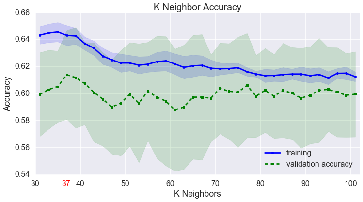

```python
#plot validation curve accuracy estimated rate vs K values
ax = plt.subplot(111)
plt.plot(param_range, train_mean, color='blue', marker='o', markersize=5, label='training')
plt.fill_between(param_range, train_mean + train_std, train_mean - train_std, alpha = 0.15, color='blue', )
plt.plot(param_range, test_mean, linestyle='--', color='green', marker='s', markersize=5, label='validation accuracy')
plt.fill_between(param_range, test_mean + test_std, test_mean - test_std, alpha=0.15, color='green')

ax.axhline(y=max(test_mean), linewidth=1, color='r', linestyle='-', alpha=0.5)
ax.axvline(x=37, linewidth=1, color='r', linestyle='-', alpha=0.5)

plt.text(35.9, .5318, r'37', fontsize=16, color='r')
plt.legend(loc='lower right')
plt.xlabel('K Neighbors')
plt.ylabel('Accuracy')
plt.title('K Neighbor Accuracy')
plt.xlim(30, 102)
plt.show();
```

#### K=37 is the best predicted accuracy rate

The training accuracy for each point K accompanies our validation accuracy so that we have a clear visual of our bias-variance tradeoff as K increases. Next we will plot the true accuracy scores of K taken from our 'results' dataframe in Problem 2.1, and see how our validation curve compares to our model's true accuracies.

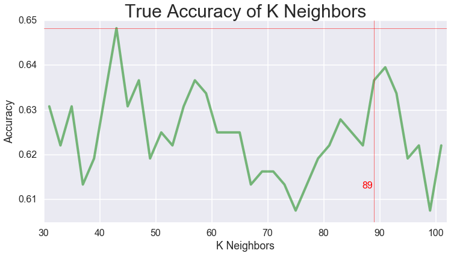

```python
#plot accuracy rate vs K values
ax = plt.subplot(111)

plt.plot(results['n'], results['accuracy'], c='green', lw=4, alpha=0.5)
ax.axhline(y=max(results['accuracy']), linewidth=1, color='r', linestyle='-', alpha=0.5)
ax.axvline(x=89, linewidth=1, color='r', linestyle='-', alpha=0.5)

ax.text(86.9, .612544, r'89', fontsize=16, color='r')
plt.title('True Accuracy of K Neighbors', size=30)
plt.xlabel('K Neighbors')
plt.ylabel('Accuracy')
plt.xlim(30, 102)
plt.show();
```

So why did we bother building a validation curve? If a model is too complex for a given training dataset - there are too many degrees of freedom or parameters in this model - the model tends to overfit the training data and does not generalize well to unseen data. It is important to choose the ideal hyperparameters of a machine learning model that will produce the best results. While simply running the model over and over again can for each hyperparameter level can be one method of determing the ideal value, some models can suffer from overfitting as a result of this process because the model gets attuned to the test data. By plotting the model validation accuracies as a function of the level of K, we can visually detect if the model suffers from high variance of high bias.

#### About that whole extra credit thing? :)

## Part 3 - Continous Feature Selection

```python
#check population size for continuous features

X_TrainA = HealthTrain[['total_los']]
PopA = X_TrainA[X_TrainA['total_los'] > 0]
print('total_los row count:', PopA.shape[0])

X_TrainB = HealthTrain[['num_op']]
PopB = X_TrainB[X_TrainB['num_op'] > 0]
print('num_op row count:', PopB.shape[0])

X_TrainC = HealthTrain[['num_er']]
PopC = X_TrainC[X_TrainC['num_er'] > 0]
print('num_er row count:', PopC.shape[0])

X_TrainD = HealthTrain[['num_ndc']]
PopD = X_TrainD[X_TrainD['num_ndc'] > 0]
print('num_ndc row count:', PopD.shape[0])

X_TrainE = HealthTrain[['pre_total_cost']]
PopE = X_TrainE[X_TrainE['pre_total_cost'] > 0]
print('pre_total_cost row count:', PopE.shape[0])

X_TrainF = HealthTrain[['pre_CCI']]
PopF = X_TrainF[X_TrainF['pre_CCI'] > 0]
print('pre_CCI row count:', PopF.shape[0])

X_TrainG = HealthTrain[['pre_rx_cost']]
PopG = X_TrainG[X_TrainG['pre_rx_cost'] > 0]
print('pre_rx_cost row count:', PopG.shape[0])

X_TrainH = HealthTrain[['num_gpi6']]
PopH = X_TrainH[X_TrainH['num_gpi6'] > 0]
print('num_gpi6 row count:', PopH.shape[0])

X_TrainI = HealthTrain[['num_ip']]
PopI = X_TrainI[X_TrainI['num_ip'] > 0]
print('num_ip row count:', PopI.shape[0])

X_TrainJ = HealthTrain[['pre_medical_cost']]
PopJ = X_TrainJ[X_TrainJ['pre_medical_cost'] > 0]
print('pre_medical_cost row count:', PopJ.shape[0])
```

```
total_los row count: 93
num_op row count: 1321
num_er row count: 244
num_ndc row count: 1355
pre_total_cost row count: 1377
pre_CCI row count: 910
pre_rx_cost row count: 1354
num_gpi6 row count: 1355
num_ip row count: 93
pre_medical_cost row count: 1321
```

The "total_los" and "num_ip" fields have very few populated records. So we will exclude them from our three alternate models. Record counts for the remaining features look good. Next p-values determined on our previous assignments were considered, and we selected the following feature combinations for the three alternate models.

- Alternate Model 1 - num_er, num_ndc, and pre_total_cost
- Alternate Model 2 - num_er and num_ndc
- Alternate Model 3 - num_op, pre_rx_cost, and pre_CCI

## Part 3 - Alternate Model 1

```python
#Test num_er, num_ndc, and pre_total_cost
X_Train1 = HealthTrain[['num_er', 'num_ndc', 'pre_total_cost']].values
X_Test1 = HealthTest[['num_er', 'num_ndc', 'pre_total_cost']].values

X_Train1_Std = sc.fit_transform(X_Train1)
X_Test1_Std = sc.fit_transform(X_Test1)
```

```python
results1 = []
for n in range(31, 102, 2):
    clf = KNeighborsClassifier(n_neighbors=n)
    clf.fit(X_Train1_Std, y_Train)
    preds = clf.predict(X_Test1_Std)
    accuracy = np.where(preds==y_Test, 1, 0).sum() / float(len(y_Test))
    results1.append([n, accuracy])

results1 = pd.DataFrame(results1, columns=["n", "accuracy"])
```

```python
results1 = results1.sort(['accuracy'], ascending=[False])
results1.head(1)

results1.head(1)
```

|  | n | accuracy |
| --- | --- | --- |
| 18 | 67 | 0.613372 |

## Part 3 - Alternate Model 2

```python
#Test only num_er and num_ndc
X_Train2 = HealthTrain[['num_er', 'num_ndc']].values
X_Test2 = HealthTest[['num_er', 'num_ndc']].values

X_Train2_Std = sc.fit_transform(X_Train2)
X_Test2_Std = sc.fit_transform(X_Test2)
```

```python
results2 = []
for n in range(31, 102, 2):
    clf = KNeighborsClassifier(n_neighbors=n)
    clf.fit(X_Train2_Std, y_Train)
    preds = clf.predict(X_Test2_Std)
    accuracy = np.where(preds==y_Test, 1, 0).sum() / float(len(y_Test))
    results2.append([n, accuracy])

results2 = pd.DataFrame(results2, columns=["n", "accuracy"])
```

```python
results2 = results2.sort(['accuracy'], ascending=[False])
results2.head(1)

results2.head(1)
```

|  | n | accuracy |
| --- | --- | --- |
| 6 | 43 | 0.607558 |

## Part 3 - Alternate Model 3

```python
#Test num_op, pre_rx_cost, and pre_CCI
X_Train3 = HealthTrain[['num_op', 'pre_rx_cost', 'pre_CCI']].values
X_Test3 = HealthTest[['num_op', 'pre_rx_cost', 'pre_CCI']].values

X_Train3_Std = sc.fit_transform(X_Train3)
X_Test3_Std = sc.fit_transform(X_Test3)
```

```python
results3 = []
for n in range(31, 102, 2):
    clf = KNeighborsClassifier(n_neighbors=n)
    clf.fit(X_Train3_Std, y_Train)
    preds = clf.predict(X_Test3_Std)
    accuracy = np.where(preds==y_Test, 1, 0).sum() / float(len(y_Test))
    results3.append([n, accuracy])

results3 = pd.DataFrame(results3, columns=["n", "accuracy"])
```

```python
results3 = results3.sort(['accuracy'], ascending=[False])
results3.head(1)

results3.head(1)
```

|  | n | accuracy |
| --- | --- | --- |
| 27 | 85 | 0.616279 |

The original model in Part 1 returned an accuracy of 64.826%.

- **Alt 1** (using num_er, num_ndc, and pre_total_cost) returned **61.337%**
- **Alt 2** (using num_er and num_ndc) returned **60.756%**
- **Alt 3** (using num_op, pre_rx_cost, and pre_CCI) returned **61.628%**

Unfortunately none of the alternative models outperformed the original model.

# Problem 3 (40 points)

In this problem you’ll continue using the healthcare data from previous problem. You’ll use the Value Distance Metric (VDM) to find the distance between symbolic feature values Northeast, Midwest, South, and West, and further use this information in KNN algorithm to predict pdc-80-flag.

1. Find all the relevant conditional probabilities for finding VDM for symbolic variable region and report your results in a table.
2. Use results in part 1 to find the distance between symbolic feature values Northeast, Midwest, South, and West using VDM equation. Report the distances in a table.
3. Use this variable (region) in conjunction with continuous variables in part 1 of problem 2 and regenerate your model, using K = 51. Compare this accuracy rate with the one from previous problem.
4. What did your model predict for the 100th, 200th, and 300th test points?

```python
HealthTrain_New = pd.concat([HealthTrain['pdc_80_flag'], pd.get_dummies(HealthTrain['regionN'])], axis=1, join='inner')
HealthTest_New = pd.concat([HealthTest['pdc_80_flag'], pd.get_dummies(HealthTest['regionN'])], axis=1, join='inner')
```

```python
HealthTrain_New = HealthTrain_New.rename(columns={1:'NE', 2:'MW', 3:'S', 4:'W'})
HealthTest_New = HealthTest_New.rename(columns={1:'NE', 2:'MW', 3:'S', 4:'W'})
HealthTrain_New.head()
```

|  | pdc_80_flag | NE | MW | S | W |
| --- | --- | --- | --- | --- | --- |
| 0 | 0 | 0.0 | 1.0 | 0.0 | 0.0 |
| 1 | 1 | 0.0 | 1.0 | 0.0 | 0.0 |
| 2 | 0 | 0.0 | 1.0 | 0.0 | 0.0 |
| 3 | 0 | 0.0 | 0.0 | 1.0 | 0.0 |
| 4 | 1 | 0.0 | 0.0 | 0.0 | 1.0 |

```python
Train_NE = HealthTrain_New[HealthTrain_New['NE'] == 1]
Train_MW = HealthTrain_New[HealthTrain_New['MW'] == 1]
Train_S = HealthTrain_New[HealthTrain_New['S'] == 1]
Train_W = HealthTrain_New[HealthTrain_New['W'] == 1]

Train_W.head()
```

|  | pdc_80_flag | NE | MW | S | W |
| --- | --- | --- | --- | --- | --- |
| 4 | 1 | 0.0 | 0.0 | 0.0 | 1.0 |
| 9 | 0 | 0.0 | 0.0 | 0.0 | 1.0 |
| 16 | 1 | 0.0 | 0.0 | 0.0 | 1.0 |
| 20 | 0 | 0.0 | 0.0 | 0.0 | 1.0 |
| 24 | 1 | 0.0 | 0.0 | 0.0 | 1.0 |

## Part 1

Find all the relevant conditional probabilities for finding VDM for symbolic variable region and report your results in a table.

```python
#setup empty table to receive Region conditional probabilities
array = ['PDC_flag_0', 'PDC_flag_1']

Table = pd.DataFrame(0, index=['NE', 'MW', 'S', 'W'], columns=array)
#Table
```

```python
#calculate Region conditional probabilities
Cond_NE_0 = ((Train_NE['pdc_80_flag'] == 0).sum())/(len(Train_NE))
Cond_MW_0 = ((Train_MW['pdc_80_flag'] == 0).sum())/(len(Train_MW))
Cond_S_0 = ((Train_S['pdc_80_flag'] == 0).sum())/(len(Train_S))
Cond_W_0 = ((Train_W['pdc_80_flag'] == 0).sum())/(len(Train_W))

Cond_NE_1 = ((Train_NE['pdc_80_flag'] == 1).sum())/(len(Train_NE))
Cond_MW_1 = ((Train_MW['pdc_80_flag'] == 1).sum())/(len(Train_MW))
Cond_S_1 = ((Train_S['pdc_80_flag'] == 1).sum())/(len(Train_S))
Cond_W_1 = ((Train_W['pdc_80_flag'] == 1).sum())/(len(Train_W))
```

```python
#populate Region conditional probabilities table
#RegCondProb.set_value('NE', 'PDC_flag_0', Cond_NE_0)
Table.iloc[0, 0] = round(Cond_NE_0, 3)
Table.iloc[1, 0] = round(Cond_MW_0, 3)
Table.iloc[2, 0] = round(Cond_S_0, 3)
Table.iloc[3, 0] = round(Cond_W_0, 3)

Table.iloc[0, 1] = round(Cond_NE_1, 3)
Table.iloc[1, 1] = round(Cond_MW_1, 3)
Table.iloc[2, 1] = round(Cond_S_1, 3)
Table.iloc[3, 1] = round(Cond_W_1, 3)

Table = Table.style.set_table_styles([{'selector': 'tr:hover', 'props': [('background-color', 'lavender')]},
                            {'selector': 'tr:nth-child(even)', 'props': [('background-color', 'lightgreen')]}])
Table
```

|  | PDC_flag_0 | PDC_flag_1 |
| --- | --- | --- |
| NE | 0.495 | 0.505 |
| MW | 0.569 | 0.431 |
| S | 0.646 | 0.354 |
| W | 0.576 | 0.424 |

## Part 2

Use results in part 1 to find the distance between symbolic feature values Northeast, Midwest, South, and West using VDM equation. Report the distances in a table.

```python
#calculate distances between each Region's conditional proabality
Dist_NE_MW = (abs(Cond_NE_0 - Cond_MW_0))**2 + (abs(Cond_NE_1 - Cond_MW_1))**2
Dist_NE_S = (abs(Cond_NE_0 - Cond_S_0))**2 + (abs(Cond_NE_1 - Cond_S_1))**2
Dist_NE_W = (abs(Cond_NE_0 - Cond_W_0))**2 + (abs(Cond_NE_1 - Cond_W_1))**2
Dist_MW_S = (abs(Cond_MW_0 - Cond_S_0))**2 + (abs(Cond_MW_1 - Cond_S_1))**2
Dist_MW_W = (abs(Cond_MW_0 - Cond_W_0))**2 + (abs(Cond_MW_1 - Cond_W_1))**2
Dist_S_W = (abs(Cond_S_0 - Cond_W_0))**2 + (abs(Cond_S_1 - Cond_W_1))**2

Dist_NE_MW
```

```
0.01068226676847841
```

```python
#setup empty table to receive Region/symbolic feature distances
Header = ['NE', 'MW', 'S', 'W']
Table_Dist = pd.DataFrame(0, index=['NE', 'MW', 'S', 'W'],
                          columns=Header)
#Table_Dist
```

```python
#populate Region distance table
Table_Dist.iloc[0, 1] = round(Dist_NE_MW, 4)
Table_Dist.iloc[1, 0] = round(Dist_NE_MW, 4)
Table_Dist.iloc[0, 2] = round(Dist_NE_S, 4)
Table_Dist.iloc[2, 0] = round(Dist_NE_S, 4)
Table_Dist.iloc[0, 3] = round(Dist_NE_W, 4)
Table_Dist.iloc[3, 0] = round(Dist_NE_W, 4)
Table_Dist.iloc[1, 2] = round(Dist_MW_S, 4)
Table_Dist.iloc[2, 1] = round(Dist_MW_S, 4)
Table_Dist.iloc[1, 3] = round(Dist_MW_W, 4)
Table_Dist.iloc[3, 1] = round(Dist_MW_W, 4)
Table_Dist.iloc[3, 2] = round(Dist_S_W, 4)
Table_Dist.iloc[2, 3] = round(Dist_S_W, 4)
Table_Dist = Table_Dist.style.set_table_styles([{'selector': 'tr:hover', 'props': [('background-color', 'lavender')]},
                            {'selector': 'tr:nth-child(even)', 'props': [('background-color', 'lightblue')]}])
Table_Dist
```

|  | NE | MW | S | W |
| --- | --- | --- | --- | --- |
| NE | 0 | 0.0107 | 0.0453 | 0.013 |
| MW | 0.0107 | 0 | 0.012 | 0.0001 |
| S | 0.0453 | 0.012 | 0 | 0.0098 |
| W | 0.013 | 0.0001 | 0.0098 | 0 |

```python
#NE=1, MW=2, S=3, W=4
Reg_TrainTest = pd.concat([HealthTrain['regionN'], HealthTest['regionN']], axis=1, join='inner')
Reg_TrainTest.columns = ['Trn_Region','Tst_Region']
Reg_TrainTest
```

|  | Trn_Region | Tst_Region |
| --- | --- | --- |
| 0 | 2 | 3 |
| 1 | 2 | 3 |
| 2 | 2 | 3 |
| 3 | 3 | 3 |
| 4 | 4 | 3 |
| 5 | 3 | 3 |
| 6 | 3 | 3 |
| 7 | 3 | 3 |
| 8 | 3 | 3 |
| 9 | 4 | 3 |
| ... | ... | ... |
| 334 | 3 | 3 |
| 335 | 3 | 1 |
| 336 | 2 | 1 |
| 337 | 2 | 1 |
| 338 | 3 | 4 |
| 339 | 2 | 1 |
| 340 | 2 | 1 |
| 341 | 3 | 4 |
| 342 | 3 | 3 |
| 343 | 3 | 3 |

344 rows × 2 columns

## Part 3

Use this variable (region) in conjunction with continuous variables in part 1 of problem 2 and regenerate your model, using K = 51. Compare this accuracy rate with the one from previous problem.

Variables:

- total_los
- num_op
- num_er
- num_ndc
- pre_total_cost
- pre_CCI

'total_los', 'num_op', 'num_er', 'num_ndc', 'pre_total_cost', 'pre_CCI'

Setting the training dataframe values

```python
#'total_los', 'num_op', 'num_er', 'num_ndc', 'pre_total_cost', 'pre_CCI'
X_Train_Std = pd.DataFrame(X_Train_Std)
X_Train_Std = pd.concat([X_Train_Std, HealthTrain.regionN], axis=1)
X_Train_Std = X_Train_Std.set_index(HealthTrain.pdc_80_flag.values)
X_Train_Std = X_Train_Std.rename(columns={0: 'total_los', 1: 'num_op', 2: 'num_er', 3: 'num_ndc', 4: 'pre_total_cost',
                                          5: 'pre_CCI', 6: 'regionN'})
X_Train_Std
```

|  | total_los | num_op | num_er | num_ndc | pre_total_cost | pre_CCI | regionN |
| --- | --- | --- | --- | --- | --- | --- | --- |
| 0 | -0.218282 | -0.775119 | -0.392157 | -0.984947 | -0.499314 | -0.902825 | 2 |
| 1 | -0.218282 | -0.031997 | -0.392157 | -0.221776 | -0.416165 | -0.902825 | 2 |
| 0 | -0.218282 | -0.031997 | -0.392157 | -0.984947 | -0.173073 | -0.902825 | 2 |
| 0 | -0.218282 | -0.775119 | -0.392157 | -0.900150 | -0.476305 | -0.902825 | 3 |
| 1 | -0.218282 | -0.527412 | -0.392157 | -0.984947 | -0.409953 | -0.902825 | 4 |
| 1 | -0.218282 | 0.339564 | -0.392157 | -0.730556 | 1.897357 | -0.037068 | 3 |
| 1 | -0.218282 | -0.527412 | -0.392157 | -0.900150 | 0.037873 | -0.037068 | 3 |
| 1 | -0.218282 | 0.215710 | -0.392157 | 4.611637 | 1.195147 | 7.754743 | 3 |
| 0 | -0.218282 | -0.527412 | -0.392157 | -0.900150 | -0.437586 | -0.902825 | 3 |
| 0 | -0.218282 | 0.958833 | -0.392157 | -0.221776 | -0.279532 | -0.902825 | 4 |
| ... | ... | ... | ... | ... | ... | ... | ... |
| 0 | -0.218282 | -0.279704 | -0.392157 | -0.815353 | -0.268577 | -0.902825 | 2 |
| 0 | -0.218282 | 0.339564 | -0.392157 | -0.560963 | -0.058355 | -0.902825 | 2 |
| 1 | -0.218282 | -0.031997 | -0.392157 | -0.136979 | -0.054572 | -0.902825 | 1 |
| 1 | -0.218282 | 21.518548 | -0.392157 | 5.883588 | 4.710716 | 2.560202 | 3 |
| 1 | -0.218282 | -0.527412 | 1.206636 | -0.645760 | -0.439861 | -0.037068 | 3 |
| 0 | -0.218282 | 0.339564 | -0.392157 | -1.069743 | -0.330637 | -0.902825 | 1 |
| 0 | -0.218282 | -0.403558 | -0.392157 | 0.287004 | -0.420466 | 0.828689 | 3 |
| 0 | -0.218282 | -0.403558 | -0.392157 | 0.626191 | -0.218827 | -0.037068 | 3 |
| 1 | -0.218282 | 0.215710 | -0.392157 | 0.541394 | -0.051181 | -0.037068 | 3 |
| 1 | -0.218282 | -0.279704 | 1.206636 | 0.032614 | 0.641427 | 2.560202 | 2 |

1378 rows × 7 columns

Setting the test dataframe values

```python
#'total_los', 'num_op', 'num_er', 'num_ndc', 'pre_total_cost', 'pre_CCI'
X_Test_Std = pd.DataFrame(X_Test_Std)
X_Test_Std = pd.concat([X_Test_Std, HealthTest.regionN], axis=1)
X_Test_Std = X_Test_Std.set_index(HealthTest.pdc_80_flag.values)
X_Test_Std = X_Test_Std.rename(columns={0: 'total_los', 1: 'num_op', 2: 'num_er', 3: 'num_ndc', 4: 'pre_total_cost',
                                        5: 'pre_CCI', 6: 'regionN'})
X_Test_Std
```

|  | total_los | num_op | num_er | num_ndc | pre_total_cost | pre_CCI | regionN |
| --- | --- | --- | --- | --- | --- | --- | --- |
| 0 | -0.174452 | 2.793373 | -0.356867 | 0.391690 | -0.040773 | -0.026940 | 3 |
| 1 | -0.174452 | -0.470900 | -0.356867 | 0.578312 | -0.392783 | -0.869432 | 3 |
| 0 | -0.174452 | -0.878934 | -0.356867 | -0.728044 | -0.510484 | -0.869432 | 3 |
| 1 | 0.544249 | 0.889214 | -0.356867 | 2.257913 | 2.574965 | -0.026940 | 3 |
| 0 | -0.174452 | -0.878934 | -0.356867 | -0.821355 | -0.514924 | -0.869432 | 3 |
| 1 | -0.174452 | -0.470900 | -0.356867 | 1.791357 | -0.108731 | -0.026940 | 3 |
| 0 | -0.174452 | -0.606911 | -0.356867 | 0.298379 | -0.304032 | -0.026940 | 3 |
| 0 | -0.174452 | -0.198877 | -0.356867 | 2.351224 | -0.022807 | 0.815552 | 3 |
| 1 | -0.174452 | -0.198877 | -0.356867 | 1.044868 | -0.231638 | 2.500536 | 3 |
| 1 | -0.174452 | -0.334888 | -0.356867 | 4.404070 | -0.412256 | -0.869432 | 3 |
| ... | ... | ... | ... | ... | ... | ... | ... |
| 0 | -0.174452 | -0.742923 | -0.356867 | 2.537847 | -0.129346 | -0.869432 | 3 |
| 0 | -0.174452 | -0.198877 | -0.356867 | 0.205068 | -0.434856 | -0.026940 | 1 |
| 0 | -0.174452 | 0.073146 | 0.835000 | -0.448111 | -0.361034 | -0.869432 | 1 |
| 0 | -0.174452 | -0.470900 | -0.356867 | 0.578312 | -0.443298 | 0.815552 | 1 |
| 1 | -0.174452 | -0.742923 | -0.356867 | -0.448111 | -0.493189 | -0.026940 | 4 |
| 1 | 1.262949 | -0.878934 | 0.835000 | -1.007978 | 0.506764 | -0.026940 | 1 |
| 1 | 9.528007 | 4.969555 | 3.218736 | 3.004403 | 5.710774 | 2.500536 | 1 |
| 1 | -0.174452 | 1.841293 | -0.356867 | -0.074866 | 0.312261 | -0.026940 | 4 |
| 0 | -0.174452 | -0.470900 | 0.835000 | -0.448111 | -0.018488 | -0.869432 | 3 |
| 0 | -0.174452 | -0.742923 | -0.356867 | -0.541422 | -0.488735 | -0.869432 | 3 |

344 rows × 7 columns

```python
Euc = euclidean_distances(X_Train_Std, X_Test_Std)
Euc = pd.DataFrame(Euc)
Euc = Euc.set_index(HealthTrain.pdc_80_flag.values)
print('Train points:', Euc.shape[0])
print('Test points:', Euc.shape[1])
Euc.head()
```

```
Train points: 1378
Test points: 344
```

|  | 0 | 1 | 2 | 3 | 4 | 5 | 6 | 7 | 8 | 9 | 10 | 11 | 12 | 13 | 14 | 15 | 16 | 17 | 18 | 19 | 20 | 21 | 22 | 23 | 24 | 25 | 26 | 27 | 28 | … |
| --- | --- | --- | --- | --- | --- | --- | --- | --- | --- | --- | --- | --- | --- | --- | --- | --- | --- | --- | --- | --- | --- | --- | --- | --- | --- | --- | --- | --- | --- | --- |
| 0 | 4.075520 | 1.884664 | 1.039799 | 5.008713 | 1.020816 | 3.118222 | 1.866465 | 3.955393 | 4.136410 | 5.499742 | 1.885791 | 2.176113 | 2.009527 | 2.196726 | 2.040986 | 2.008009 | 2.005814 | 2.864649 | 1.351312 | 2.009442 | 3.676248 | 3.591246 | 2.168156 | 3.351575 | 1.140987 | 0.246976 | 1.010069 | 0.321168 | 1.594164 | … |
| 1 | 3.204733 | 1.355583 | 1.409534 | 4.277174 | 1.445971 | 2.471881 | 1.544021 | 3.280076 | 3.775224 | 4.742836 | 1.383539 | 2.024558 | 2.195029 | 2.337751 | 2.110484 | 2.208026 | 2.280865 | 2.540551 | 1.569615 | 2.195242 | 3.298893 | 2.982550 | 2.083271 | 3.014641 | 1.139804 | 0.834327 | 1.487083 | 0.768997 | 1.656310 | … |
| 0 | 3.415507 | 1.920669 | 1.378923 | 4.611545 | 1.365726 | 3.110463 | 1.940345 | 3.890559 | 4.091144 | 5.494974 | 1.579114 | 2.159320 | 2.104708 | 2.285789 | 2.082704 | 2.154062 | 2.190621 | 2.948001 | 1.489330 | 2.105815 | 3.361144 | 3.536531 | 2.255407 | 2.891005 | 1.203705 | 0.665643 | 1.357690 | 0.683874 | 1.551167 | … |
| 0 | 3.919568 | 1.513161 | 0.214120 | 4.837715 | 0.150861 | 2.870925 | 1.504920 | 3.750351 | 3.970018 | 5.323245 | 1.561175 | 1.270847 | 1.016266 | 1.343471 | 1.061764 | 1.005917 | 1.008191 | 2.211884 | 0.897134 | 1.016271 | 3.189845 | 3.069261 | 1.252397 | 2.852488 | 0.479748 | 1.019362 | 0.129437 | 1.031595 | 1.873896 | … |
| 1 | 3.850893 | 1.857834 | 1.097249 | 4.876738 | 1.079643 | 3.093886 | 1.853322 | 3.917121 | 4.104377 | 5.484784 | 1.747895 | 0.752047 | 0.139768 | 0.899462 | 0.273508 | 0.291018 | 0.365804 | 2.055482 | 1.344436 | 0.143400 | 2.953203 | 2.937390 | 0.825040 | 2.485046 | 1.097357 | 2.009907 | 1.069480 | 2.019176 | 2.520786 | … |

5 rows × 344 columns

```python
EucMin51 = np.array([Euc[c].nsmallest(51).index.values for c in Euc])
EucMin51 = pd.DataFrame(EucMin51)
EucMin51.head()
```

|  | 0 | 1 | 2 | 3 | 4 | 5 | 6 | 7 | 8 | 9 | 10 | 11 | 12 | 13 | 14 | 15 | 16 | 17 | 18 | 19 | 20 | 21 | 22 | 23 | 24 | 25 | 26 | 27 | 28 | … |
| --- | --- | --- | --- | --- | --- | --- | --- | --- | --- | --- | --- | --- | --- | --- | --- | --- | --- | --- | --- | --- | --- | --- | --- | --- | --- | --- | --- | --- | --- | --- |
| 0 | 0 | 0 | 1 | 1 | 0 | 0 | 0 | 1 | 1 | 0 | 1 | 0 | 0 | 0 | 1 | 0 | 1 | 0 | 1 | 1 | 1 | 0 | 0 | 1 | 0 | 0 | 0 | 0 | 0 | … |
| 1 | 1 | 0 | 0 | 0 | 0 | 0 | 1 | 0 | 1 | 1 | 1 | 1 | 0 | 0 | 1 | 1 | 1 | 1 | 1 | 1 | 0 | 1 | 1 | 0 | 0 | 1 | 0 | 0 | 0 | … |
| 2 | 0 | 0 | 0 | 0 | 0 | 0 | 0 | 0 | 0 | 0 | 0 | 1 | 0 | 1 | 1 | 0 | 1 | 0 | 0 | 1 | 0 | 0 | 0 | 1 | 0 | 0 | 1 | 0 | 0 | … |
| 3 | 1 | 1 | 0 | 0 | 1 | 1 | 0 | 0 | 0 | 0 | 1 | 0 | 1 | 0 | 0 | 0 | 0 | 1 | 1 | 1 | 1 | 0 | 0 | 0 | 1 | 1 | 0 | 0 | 0 | … |
| 4 | 0 | 0 | 0 | 0 | 1 | 0 | 0 | 0 | 0 | 0 | 0 | 1 | 0 | 0 | 0 | 0 | 0 | 0 | 1 | 0 | 0 | 0 | 0 | 1 | 1 | 1 | 1 | 1 | 0 | … |

```python
from scipy.stats import mode

Class = mode(EucMin51)
Class
```

```
ModeResult(mode=array([[0, 0, 0, 0, 0, 0, 0, 0, 0, 0, 0, 0, 0, 0, 0, 0, 0, 0, 0, 0, 0, 0,
        0, 0, 0, 0, 0, 0, 0, 0, 0, 0, 0, 0, 0, 0, 0, 0, 0, 0, 0, 0, 0, 0,
        0, 0, 0, 0, 0, 0, 0]]), count=array([[215, 201, 225, 220, 228, 221, 224, 213, 203, 210, 221, 223, 218,
        209, 197, 225, 214, 220, 216, 203, 215, 201, 203, 196, 205, 215,
        216, 225, 224, 209, 214, 202, 209, 204, 206, 204, 216, 212, 201,
        213, 195, 213, 212, 211, 219, 196, 205, 217, 227, 208, 192]]))
```

```python
Class = EucMin51.mode(axis=1)
```

```python
Classes = pd.concat([Class, HealthTest.pdc_80_flag], axis=1)
Classes.columns = ['generatedLabel','testLabel']
Classes.head()
```

|  | generatedLabel | testLabel |
| --- | --- | --- |
| 0 | 0 | 0 |
| 1 | 1 | 1 |
| 2 | 0 | 0 |
| 3 | 0 | 1 |
| 4 | 0 | 0 |

```python
Classification = pd.Series(Classes.generatedLabel == Classes.testLabel)
Classification = Classification.astype(int)
Classification.head()
```

```
0    1
1    1
2    1
3    0
4    1
dtype: int64
```

```python
ClAccuracy = ((Classification==1).sum())/344
print(round(ClAccuracy, 3))
```

```
0.628
```

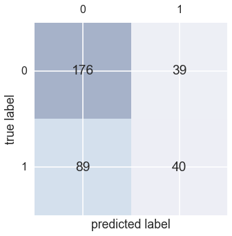

```python
confmateuc = confusion_matrix(y_true=Classes.testLabel, y_pred=Classes.generatedLabel)

fig, ax = plt.subplots(figsize=(5, 5))
ax.matshow(confmateuc, cmap=plt.cm.Blues, alpha=0.3)
for i in range(confmateuc.shape[0]):
    for j in range(confmateuc.shape[1]):
        ax.text(x=j, y=i, s=confmateuc[i, j], va='center', ha='center')
plt.xlabel('predicted label')
plt.ylabel('true label')
plt.show();
```

```python
#Evaluating against Python's built-in KNN model
knn = KNeighborsClassifier(n_neighbors=51, metric='euclidean')
knn.fit(X_Train_Std, y_Train)

print("Accuracy: %.03f" % knn.score(X_Test_Std, y_Test))
#Same accuracy scores
```

```
Accuracy: 0.628
```

## Method 2

Unfortunately the above method does not calculate the Value Distance Metric for the regions, so we will calculate that manually into a 1300ish by 300ish matrix and operate it onto the euclidean distances if the same dimensions, to accurately incorporate the region data into the continuous data.

```python
#Reusing the euclidean distance function used above, this time only on continuous features
#We will manually calculate the distances for the last feature and add it into the continuous dataframe

Euc2 = euclidean_distances(X_Train_Std.iloc[:, 0:5], X_Test_Std.iloc[:, 0:5])
Euc2 = pd.DataFrame(Euc2)
Euc2 = Euc2.set_index(HealthTrain.pdc_80_flag.values)
print('Train points:', Euc2.shape[0])
print('Test points:', Euc2.shape[1])
Euc2.head()
```

```
Train points: 1378
Test points: 344
```

|  | 0 | 1 | 2 | 3 | 4 | 5 | 6 | 7 | 8 | 9 | 10 | 11 | 12 | 13 | 14 | 15 | 16 | 17 | 18 | 19 | 20 | 21 | 22 | 23 | 24 | 25 | 26 | 27 | 28 | … |
| --- | --- | --- | --- | --- | --- | --- | --- | --- | --- | --- | --- | --- | --- | --- | --- | --- | --- | --- | --- | --- | --- | --- | --- | --- | --- | --- | --- | --- | --- | --- |
| 0 | 3.852621 | 1.597136 | 0.282962 | 4.829082 | 0.202360 | 2.820662 | 1.310160 | 3.419403 | 2.127679 | 5.407962 | 1.337548 | 0.856944 | 0.192572 | 0.241727 | 0.405597 | 0.176026 | 0.148907 | 1.854465 | 0.242632 | 0.191681 | 2.957638 | 2.851293 | 0.836531 | 2.689227 | 0.548394 | 0.244708 | 0.138289 | 0.319427 | 1.331985 | … |
| 1 | 2.916015 | 0.914598 | 0.992810 | 4.065346 | 1.043895 | 2.083992 | 0.785384 | 2.608846 | 1.292073 | 4.636095 | 0.383414 | 0.312604 | 0.903901 | 0.835407 | 0.673073 | 0.935021 | 1.096007 | 1.298933 | 0.834576 | 0.904417 | 2.472958 | 2.031854 | 0.582154 | 2.255426 | 0.545930 | 0.833658 | 1.100137 | 0.768271 | 1.405770 | … |
| 0 | 3.146190 | 1.639467 | 0.948848 | 4.415787 | 0.929566 | 2.812082 | 1.413424 | 3.344194 | 2.038282 | 5.403112 | 0.852306 | 0.813355 | 0.654737 | 0.676503 | 0.580121 | 0.799292 | 0.893143 | 1.980791 | 0.671514 | 0.658287 | 2.555409 | 2.782064 | 1.041992 | 2.087293 | 0.669172 | 0.664805 | 0.917718 | 0.683058 | 1.280213 | … |
| 0 | 3.820450 | 1.512793 | 0.211500 | 4.757763 | 0.147119 | 2.734052 | 1.223768 | 3.333514 | 2.044059 | 5.323140 | 1.292321 | 0.783541 | 0.177992 | 0.194273 | 0.355285 | 0.103704 | 0.123833 | 1.767840 | 0.194100 | 0.178021 | 2.899645 | 2.766440 | 0.753249 | 2.671250 | 0.478584 | 0.194893 | 0.125055 | 0.251142 | 1.320724 | … |
| 1 | 3.614167 | 1.565386 | 0.450377 | 4.692057 | 0.405605 | 2.793736 | 1.291367 | 3.375059 | 2.064714 | 5.392749 | 1.134885 | 0.751306 | 0.135720 | 0.204591 | 0.271462 | 0.289096 | 0.364277 | 1.859525 | 0.200832 | 0.139458 | 2.820326 | 2.803763 | 0.824364 | 2.484821 | 0.450641 | 0.196501 | 0.377720 | 0.275604 | 1.259837 | … |

5 rows × 344 columns

```python
#setup empty table again to receive Region/symbolic feature distances
Header = [1, 2, 3, 4]
Deltas = pd.DataFrame(0, index=[1, 2, 3, 4],
                          columns=Header)
```

```python
Deltas.iloc[0, 1] = round(Dist_NE_MW, 4)
Deltas.iloc[1, 0] = round(Dist_NE_MW, 4)
Deltas.iloc[0, 2] = round(Dist_NE_S, 4)
Deltas.iloc[2, 0] = round(Dist_NE_S, 4)
Deltas.iloc[0, 3] = round(Dist_NE_W, 4)
Deltas.iloc[3, 0] = round(Dist_NE_W, 4)
Deltas.iloc[1, 2] = round(Dist_MW_S, 4)
Deltas.iloc[2, 1] = round(Dist_MW_S, 4)
Deltas.iloc[1, 3] = round(Dist_MW_W, 4)
Deltas.iloc[3, 1] = round(Dist_MW_W, 4)
Deltas.iloc[3, 2] = round(Dist_S_W, 4)
Deltas.iloc[2, 3] = round(Dist_S_W, 4)
```

```python
Deltas
```

|  | 1 | 2 | 3 | 4 |
| --- | --- | --- | --- | --- |
| 1 | 0.0000 | 0.0107 | 0.0453 | 0.0130 |
| 2 | 0.0107 | 0.0000 | 0.0120 | 0.0001 |
| 3 | 0.0453 | 0.0120 | 0.0000 | 0.0098 |
| 4 | 0.0130 | 0.0001 | 0.0098 | 0.0000 |

```python
X_Test_Std.head()
```

|  | total_los | num_op | num_er | num_ndc | pre_total_cost | pre_CCI | regionN |
| --- | --- | --- | --- | --- | --- | --- | --- |
| 0 | -0.174452 | 2.793373 | -0.356867 | 0.391690 | -0.040773 | -0.026940 | 3 |
| 1 | -0.174452 | -0.470900 | -0.356867 | 0.578312 | -0.392783 | -0.869432 | 3 |
| 0 | -0.174452 | -0.878934 | -0.356867 | -0.728044 | -0.510484 | -0.869432 | 3 |
| 1 | 0.544249 | 0.889214 | -0.356867 | 2.257913 | 2.574965 | -0.026940 | 3 |
| 0 | -0.174452 | -0.878934 | -0.356867 | -0.821355 | -0.514924 | -0.869432 | 3 |

```python
from scipy.spatial import distance

Delts = []
for i in X_Test_Std.regionN:
    for j in X_Train_Std.regionN:
        Output = Deltas.loc[i, j]
        Delts.append(Output)
```

```python
Delts = np.array(Delts)
```

```python
Delts = np.split(Delts, 344)
Xv = pd.DataFrame(Delts)
Xv.head()
```

|  | 0 | 1 | 2 | 3 | 4 | 5 | 6 | 7 | 8 | 9 | 10 | 11 | 12 | 13 | 14 | 15 | 16 | 17 | 18 | 19 | 20 | 21 | 22 | 23 | 24 | 25 | 26 | 27 | 28 | … |
| --- | --- | --- | --- | --- | --- | --- | --- | --- | --- | --- | --- | --- | --- | --- | --- | --- | --- | --- | --- | --- | --- | --- | --- | --- | --- | --- | --- | --- | --- | --- |
| 0 | 0.012 | 0.012 | 0.012 | 0.0 | 0.0098 | 0.0 | 0.0 | 0.0 | 0.0 | 0.0098 | 0.0 | 0.0 | 0.012 | 0.012 | 0.0 | 0.0 | 0.0098 | 0.0453 | 0.0 | 0.0453 | 0.0098 | 0.0 | 0.0 | 0.0 | 0.0098 | 0.012 | 0.0 | 0.0098 | 0.0 | … |
| 1 | 0.012 | 0.012 | 0.012 | 0.0 | 0.0098 | 0.0 | 0.0 | 0.0 | 0.0 | 0.0098 | 0.0 | 0.0 | 0.012 | 0.012 | 0.0 | 0.0 | 0.0098 | 0.0453 | 0.0 | 0.0453 | 0.0098 | 0.0 | 0.0 | 0.0 | 0.0098 | 0.012 | 0.0 | 0.0098 | 0.0 | … |
| 2 | 0.012 | 0.012 | 0.012 | 0.0 | 0.0098 | 0.0 | 0.0 | 0.0 | 0.0 | 0.0098 | 0.0 | 0.0 | 0.012 | 0.012 | 0.0 | 0.0 | 0.0098 | 0.0453 | 0.0 | 0.0453 | 0.0098 | 0.0 | 0.0 | 0.0 | 0.0098 | 0.012 | 0.0 | 0.0098 | 0.0 | … |
| 3 | 0.012 | 0.012 | 0.012 | 0.0 | 0.0098 | 0.0 | 0.0 | 0.0 | 0.0 | 0.0098 | 0.0 | 0.0 | 0.012 | 0.012 | 0.0 | 0.0 | 0.0098 | 0.0453 | 0.0 | 0.0453 | 0.0098 | 0.0 | 0.0 | 0.0 | 0.0098 | 0.012 | 0.0 | 0.0098 | 0.0 | … |
| 4 | 0.012 | 0.012 | 0.012 | 0.0 | 0.0098 | 0.0 | 0.0 | 0.0 | 0.0 | 0.0098 | 0.0 | 0.0 | 0.012 | 0.012 | 0.0 | 0.0 | 0.0098 | 0.0453 | 0.0 | 0.0453 | 0.0098 | 0.0 | 0.0 | 0.0 | 0.0098 | 0.012 | 0.0 | 0.0098 | 0.0 | … |

5 rows × 1378 columns

```python
Xv = Xv.T
print(Xv.shape[0])
print(Xv.shape[1])
```

```
1378
344
```

```python
VecFin = Xv + Euc2
VecFin.head()
```

|  | 0 | 1 | 2 | 3 | 4 | 5 | 6 | 7 | 8 | 9 | 10 | 11 | 12 | 13 | 14 | 15 | 16 | 17 | 18 | 19 | 20 | 21 | 22 | 23 | 24 | 25 | 26 | 27 | 28 | … |
| --- | --- | --- | --- | --- | --- | --- | --- | --- | --- | --- | --- | --- | --- | --- | --- | --- | --- | --- | --- | --- | --- | --- | --- | --- | --- | --- | --- | --- | --- | --- |
| 0 | 3.864621 | 1.609136 | 0.294962 | 4.841082 | 0.214360 | 2.832662 | 1.322160 | 3.431403 | 2.139679 | 5.419962 | 1.349548 | 0.857044 | 0.192672 | 0.241827 | 0.405697 | 0.176126 | 0.149007 | 1.854565 | 0.254632 | 0.191781 | 2.957738 | 2.851393 | 0.836631 | 2.689327 | 0.560394 | 0.244708 | 0.150289 | 0.319427 | 1.331985 | … |
| 0 | 3.158190 | 1.651467 | 0.960848 | 4.427787 | 0.941566 | 2.824082 | 1.425424 | 3.356194 | 2.050282 | 5.415112 | 0.864306 | 0.813455 | 0.654837 | 0.676603 | 0.580221 | 0.799392 | 0.893243 | 1.980891 | 0.683514 | 0.658387 | 2.555509 | 2.782164 | 1.042092 | 2.087393 | 0.681172 | 0.664805 | 0.929718 | 0.683058 | 1.280213 | … |
| 0 | 3.832450 | 1.524793 | 0.223500 | 4.769763 | 0.159119 | 2.746052 | 1.235768 | 3.345514 | 2.056059 | 5.335140 | 1.304321 | 0.783641 | 0.178092 | 0.194373 | 0.355385 | 0.103804 | 0.123933 | 1.767940 | 0.206100 | 0.178121 | 2.899745 | 2.766540 | 0.753349 | 2.671350 | 0.490584 | 0.194893 | 0.137055 | 0.251142 | 1.320724 | … |
| 0 | 3.597678 | 1.493289 | 0.414080 | 4.663704 | 0.384725 | 2.724696 | 1.221874 | 3.306629 | 1.996089 | 5.320072 | 1.095075 | 0.671903 | 0.104801 | 0.133998 | 0.189992 | 0.243197 | 0.356420 | 1.777445 | 0.142427 | 0.107649 | 2.803778 | 2.722147 | 0.739015 | 2.491377 | 0.380661 | 0.127026 | 0.376570 | 0.197843 | 1.254706 | … |
| 0 | 1.961885 | 1.655249 | 1.932989 | 3.870051 | 1.960193 | 2.487718 | 1.663024 | 2.845672 | 1.729597 | 4.817512 | 0.643798 | 1.299623 | 1.724138 | 1.690180 | 1.527016 | 1.818061 | 1.971655 | 2.016599 | 1.700781 | 1.725016 | 2.500847 | 2.324269 | 1.578648 | 1.912079 | 1.483742 | 1.687090 | 1.990892 | 1.653534 | 1.881776 | … |

5 rows × 344 columns

```python
VecFinmin51 = np.array([VecFin[c].nsmallest(51).index.values for c in VecFin])
VecFinmin51 = pd.DataFrame(VecFinmin51)
VecFinmin51.head()
```

|  | 0 | 1 | 2 | 3 | 4 | 5 | 6 | 7 | 8 | 9 | 10 | 11 | 12 | 13 | 14 | 15 | 16 | 17 | 18 | 19 | 20 | 21 | 22 | 23 | 24 | 25 | 26 | 27 | 28 | … |
| --- | --- | --- | --- | --- | --- | --- | --- | --- | --- | --- | --- | --- | --- | --- | --- | --- | --- | --- | --- | --- | --- | --- | --- | --- | --- | --- | --- | --- | --- | --- |
| 0 | 0 | 0 | 1 | 1 | 0 | 1 | 0 | 0 | 0 | 1 | 1 | 1 | 1 | 0 | 1 | 1 | 0 | 0 | 1 | 0 | 0 | 0 | 0 | 0 | 0 | 0 | 0 | 1 | 1 | … |
| 1 | 0 | 0 | 1 | 1 | 0 | 0 | 1 | 1 | 0 | 1 | 0 | 0 | 1 | 0 | 0 | 0 | 1 | 0 | 1 | 1 | 1 | 0 | 1 | 0 | 1 | 1 | 0 | 0 | 1 | … |
| 2 | 0 | 0 | 0 | 0 | 0 | 0 | 1 | 0 | 0 | 1 | 0 | 0 | 0 | 0 | 0 | 0 | 0 | 0 | 1 | 0 | 0 | 1 | 0 | 0 | 1 | 1 | 1 | 1 | 1 | … |
| 3 | 0 | 0 | 1 | 1 | 1 | 1 | 1 | 0 | 0 | 0 | 0 | 0 | 0 | 0 | 1 | 1 | 1 | 1 | 0 | 0 | 0 | 0 | 0 | 1 | 1 | 1 | 1 | 0 | 1 | … |
| 4 | 1 | 0 | 0 | 1 | 0 | 0 | 1 | 0 | 0 | 1 | 0 | 0 | 0 | 0 | 0 | 0 | 0 | 0 | 0 | 1 | 0 | 0 | 0 | 0 | 0 | 0 | 0 | 0 | 0 | … |

```python
ClassF = VecFinmin51.mode(axis=1)
ClassF
```

|  | 0 |
| --- | --- |
| 0 | 0 |
| 1 | 0 |
| 2 | 0 |
| 3 | 0 |
| 4 | 0 |
| 5 | 0 |
| 6 | 1 |
| 7 | 0 |
| 8 | 1 |
| 9 | 1 |
| ... | ... |
| 334 | 0 |
| 335 | 0 |
| 336 | 0 |
| 337 | 0 |
| 338 | 0 |
| 339 | 0 |
| 340 | 0 |
| 341 | 0 |
| 342 | 0 |
| 343 | 0 |

344 rows × 1 columns

```python
ClassesF = pd.concat([ClassF, HealthTest.pdc_80_flag], axis=1)
ClassesF.columns = ['generatedLabel','testLabel']
ClassesF.head()
```

|  | generatedLabel | testLabel |
| --- | --- | --- |
| 0 | 0 | 0 |
| 1 | 0 | 1 |
| 2 | 0 | 0 |
| 3 | 0 | 1 |
| 4 | 0 | 0 |

```python
ClassificationF = pd.Series(ClassesF.generatedLabel == ClassesF.testLabel)
ClassificationF = ClassificationF.astype(int)
ClassificationF.head()
```

```
0    1
1    0
2    1
3    0
4    1
dtype: int64
```

```python
ClAccuracy = ((Classification==1).sum())/344
print(round(ClAccuracy, 3))
```

```
0.628
```

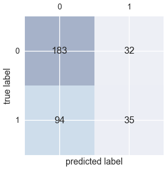

```python
confmatF = confusion_matrix(y_true=ClassesF.testLabel, y_pred=ClassesF.generatedLabel)

fig, ax = plt.subplots(figsize=(5, 5))
ax.matshow(confmatF, cmap=plt.cm.Blues, alpha=0.3)
for i in range(confmatF.shape[0]):
    for j in range(confmatF.shape[1]):
        ax.text(x=j, y=i, s=confmatF[i, j], va='center', ha='center')
plt.xlabel('predicted label')
plt.ylabel('true label')
plt.show();
```

## Part 4

What did your model predict for the 100th, 200th, and 300th test points?

```python
print('100th test point [predicted, true]:', ClassesF.iloc[99].values)
print('200th test point [predicted, true]:', ClassesF.iloc[199].values)
print('300th test point [predicted, true]:', ClassesF.iloc[299].values)
```

```
100th test point [predicted, true]: [0 0]
200th test point [predicted, true]: [0 0]
300th test point [predicted, true]: [0 0]
```